# Historical housing price prediction

### **Historical housing data contains the data of sold houses from 1872 to 2010 with its 81 features of house like Areas, zoning, building type, basement features, garage features, year built, year sold, sale price and many more**

### **Historical housing data is very important in real estate is because we get to explore the percentage/rate of sales prices changing year by year and in what features or category the prices have changed. So that it will help in finding out the future sales price of these houses.**

### **Loading the data :-**

```python
import warnings
warnings.filterwarnings('ignore')

#importing the libraries
import numpy as np
import pandas as pd
import matplotlib.pyplot as plt
import seaborn as sns
%matplotlib inline
```

```python
house=pd.read_csv('Historical Data.csv')
pd.set_option("display.max_rows",None)
pd.set_option("display.max_columns",None)
```

### **Shape of the table :-**

```python
house.head()
```

|  | Id | MSSubClass | MSZoning | LotFrontage | LotArea | Street | Alley | LotShape | LandContour | Utilities | LotConfig | LandSlope | Neighborhood | Condition1 | Condition2 | BldgType | HouseStyle | OverallQual | OverallCond | YearBuilt | YearRemodAdd | RoofStyle | RoofMatl | Exterior1st | Exterior2nd | MasVnrType | MasVnrArea | ExterQual | ExterCond | … |
| --- | --- | --- | --- | --- | --- | --- | --- | --- | --- | --- | --- | --- | --- | --- | --- | --- | --- | --- | --- | --- | --- | --- | --- | --- | --- | --- | --- | --- | --- | --- |
| 0 | 1 | 60 | RL | 65.0 | 8450 | Pave | NaN | Reg | Lvl | AllPub | Inside | Gtl | CollgCr | Norm | Norm | 1Fam | 2Story | 7 | 5 | 2003 | 2003 | Gable | CompShg | VinylSd | VinylSd | BrkFace | 196.0 | Gd | TA | … |
| 1 | 2 | 20 | RL | 80.0 | 9600 | Pave | NaN | Reg | Lvl | AllPub | FR2 | Gtl | Veenker | Feedr | Norm | 1Fam | 1Story | 6 | 8 | 1976 | 1976 | Gable | CompShg | MetalSd | MetalSd | None | 0.0 | TA | TA | … |
| 2 | 3 | 60 | RL | 68.0 | 11250 | Pave | NaN | IR1 | Lvl | AllPub | Inside | Gtl | CollgCr | Norm | Norm | 1Fam | 2Story | 7 | 5 | 2001 | 2002 | Gable | CompShg | VinylSd | VinylSd | BrkFace | 162.0 | Gd | TA | … |
| 3 | 4 | 70 | RL | 60.0 | 9550 | Pave | NaN | IR1 | Lvl | AllPub | Corner | Gtl | Crawfor | Norm | Norm | 1Fam | 2Story | 7 | 5 | 1915 | 1970 | Gable | CompShg | Wd Sdng | Wd Shng | None | 0.0 | TA | TA | … |
| 4 | 5 | 60 | RL | 84.0 | 14260 | Pave | NaN | IR1 | Lvl | AllPub | FR2 | Gtl | NoRidge | Norm | Norm | 1Fam | 2Story | 8 | 5 | 2000 | 2000 | Gable | CompShg | VinylSd | VinylSd | BrkFace | 350.0 | Gd | TA | … |

```python
house.shape
```

```
(1460, 81)
```

### **Finding the number of null values, D-type for every column :-**

```python
house.isnull().sum()  # Number of null values for each column
```

```
Id                  0
MSSubClass          0
MSZoning            0
LotFrontage       259
LotArea             0
Street              0
Alley            1369
LotShape            0
LandContour         0
Utilities           0
LotConfig           0
LandSlope           0
Neighborhood        0
Condition1          0
Condition2          0
BldgType            0
HouseStyle          0
OverallQual         0
OverallCond         0
YearBuilt           0
YearRemodAdd        0
RoofStyle           0
RoofMatl            0
Exterior1st         0
Exterior2nd         0
MasVnrType          8
MasVnrArea          8
ExterQual           0
ExterCond           0
Foundation          0
BsmtQual           37
BsmtCond           37
BsmtExposure       38
BsmtFinType1       37
BsmtFinSF1          0
BsmtFinType2       38
BsmtFinSF2          0
BsmtUnfSF           0
TotalBsmtSF         0
Heating             0
```

[output cut: 27 more lines]

```
OpenPorchSF         0
EnclosedPorch       0
3SsnPorch           0
ScreenPorch         0
PoolArea            0
PoolQC           1453
Fence            1179
MiscFeature      1406
MiscVal             0
MoSold              0
YrSold              0
SaleType            0
SaleCondition       0
SalePrice           0
dtype: int64
```

```python
house.isnull().any().sum()
```

```
19
```

### **There are 19 null columns.**

```python
house.info()
```

```
<class 'pandas.core.frame.DataFrame'>
RangeIndex: 1460 entries, 0 to 1459
Data columns (total 81 columns):
 #   Column         Non-Null Count  Dtype
---  ------         --------------  -----
 0   Id             1460 non-null   int64
 1   MSSubClass     1460 non-null   int64
 2   MSZoning       1460 non-null   object
 3   LotFrontage    1201 non-null   float64
 4   LotArea        1460 non-null   int64
 5   Street         1460 non-null   object
 6   Alley          91 non-null     object
 7   LotShape       1460 non-null   object
 8   LandContour    1460 non-null   object
 9   Utilities      1460 non-null   object
```

[output cut: 73 more lines]

### **Percentage of null values :-**

```python
null_columns=house.columns[house.isnull().any()]  #shows columns with null values
house[null_columns].isnull().sum()*100/len(house) # percentage of null values in columns
```

```
LotFrontage     17.739726
Alley           93.767123
MasVnrType       0.547945
MasVnrArea       0.547945
BsmtQual         2.534247
BsmtCond         2.534247
BsmtExposure     2.602740
BsmtFinType1     2.534247
BsmtFinType2     2.602740
Electrical       0.068493
FireplaceQu     47.260274
GarageType       5.547945
GarageYrBlt      5.547945
GarageFinish     5.547945
GarageQual       5.547945
GarageCond       5.547945
PoolQC          99.520548
Fence           80.753425
MiscFeature     96.301370
dtype: float64
```

### **Handling the missing values:-**

### **1. The first null column is LotFrontage. It consists of measurements of Lot frontage. I will use average of measurements of Lot frontage to fill up the missing data'**

```python
house['LotFrontage'].fillna(value=house['LotFrontage'].mean(), inplace= True)
```

### **2. The second null column is Alley. There are two categories Grvl and Pave with 3 and 2 percentage. Also, it got 93.76% of Null values. In this case, we are going to make a new category called 'NA' (no alley access) for all null values**

```python
house['Alley'].fillna(value='NA', inplace= True)
```

### **3. The third null column is MasVnrType. Since we are not sure about the type of MasVnr that missing values could be. We are going to fill the missing values with 'None' category**

```python
house['MasVnrType'].fillna(value='None', inplace= True)
```

### **4. The fourth null column is MasVnrArea. When we observe the MasVnrArea column in DataFrame, we notice that majority of areas are filled with '0'. Since we do not know the missing values, We can assume that missing values as '0'**

```python
house['MasVnrArea'].fillna(value='0', inplace= True)
```

### **5. The fifth to ninth null columns are all basement features column. Missing values in all of these columns are considered as there are no basement. So all the missing values in these columns can be filled with new category called 'NA' (no basement)**

```python
house['BsmtQual'].fillna(value='NA', inplace= True)
house['BsmtCond'].fillna(value='NA', inplace= True)
house['BsmtExposure'].fillna(value='NA', inplace= True)
house['BsmtFinType1'].fillna(value='NA', inplace= True)
house['BsmtFinType2'].fillna(value='NA', inplace= True)
```

### **6. The tenth null column is Electrical. Here the category 'SBrkr' has highest frequency of 91.36%. We can use 'SBrkr' category can be filled on missing values**

```python
house['Electrical'].fillna(value='SBrkr', inplace= True)
```

### **7. The eleventh null column is FireplaceQu. Similar to basement null columns, Missing values can be filled with new category called 'NA' (No fireplace)**

```python
house['FireplaceQu'].fillna(value ='NA', inplace=True)
```

```python
house['GarageType'].fillna(value='NA', inplace= True)
house['GarageYrBlt'] = house['GarageYrBlt'].fillna(house['YearBuilt'], inplace=False)
house['GarageFinish'].fillna(value='NA', inplace= True)
house['GarageQual'].fillna(value='NA', inplace= True)
house['GarageCond'].fillna(value='NA', inplace= True)
```

### **9. The seventeenth null column is PoolQC. we use category 'NA' (No pool) on missing values similar to above null columns.**

```python
house['PoolQC'].fillna(value='NA', inplace= True)
```

### **10. The Eighteenth null column is Fence. we use category 'NA' (No fence) on missing values similar to above null columns.**

```python
house['Fence'].fillna(value='NA', inplace= True)
```

### **11. The Last null column is MiscFeature. we use category 'None' on missing values similar to third null columns.**

```python
house['MiscFeature'].fillna(value='None', inplace= True)
```

### **Checking for null values:-**

```python
house.isnull().sum()
```

```
Id               0
MSSubClass       0
MSZoning         0
LotFrontage      0
LotArea          0
Street           0
Alley            0
LotShape         0
LandContour      0
Utilities        0
LotConfig        0
LandSlope        0
Neighborhood     0
Condition1       0
Condition2       0
BldgType         0
HouseStyle       0
OverallQual      0
OverallCond      0
YearBuilt        0
YearRemodAdd     0
RoofStyle        0
RoofMatl         0
Exterior1st      0
Exterior2nd      0
MasVnrType       0
MasVnrArea       0
ExterQual        0
ExterCond        0
Foundation       0
BsmtQual         0
BsmtCond         0
BsmtExposure     0
BsmtFinType1     0
BsmtFinSF1       0
BsmtFinType2     0
BsmtFinSF2       0
BsmtUnfSF        0
TotalBsmtSF      0
Heating          0
```

[output cut: 27 more lines]

```
OpenPorchSF      0
EnclosedPorch    0
3SsnPorch        0
ScreenPorch      0
PoolArea         0
PoolQC           0
Fence            0
MiscFeature      0
MiscVal          0
MoSold           0
YrSold           0
SaleType         0
SaleCondition    0
SalePrice        0
dtype: int64
```

```python
house.isnull().any().sum()
```

```
0
```

### **Therefore, there are no null values, Data is cleaned**

```python
house.isnull().sum()
```

```
Id               0
MSSubClass       0
MSZoning         0
LotFrontage      0
LotArea          0
Street           0
Alley            0
LotShape         0
LandContour      0
Utilities        0
LotConfig        0
LandSlope        0
Neighborhood     0
Condition1       0
Condition2       0
BldgType         0
HouseStyle       0
OverallQual      0
OverallCond      0
YearBuilt        0
YearRemodAdd     0
RoofStyle        0
RoofMatl         0
Exterior1st      0
Exterior2nd      0
MasVnrType       0
MasVnrArea       0
ExterQual        0
ExterCond        0
Foundation       0
BsmtQual         0
BsmtCond         0
BsmtExposure     0
BsmtFinType1     0
BsmtFinSF1       0
BsmtFinType2     0
BsmtFinSF2       0
BsmtUnfSF        0
TotalBsmtSF      0
Heating          0
```

[output cut: 27 more lines]

```
OpenPorchSF      0
EnclosedPorch    0
3SsnPorch        0
ScreenPorch      0
PoolArea         0
PoolQC           0
Fence            0
MiscFeature      0
MiscVal          0
MoSold           0
YrSold           0
SaleType         0
SaleCondition    0
SalePrice        0
dtype: int64
```

# **Data exploration and visualization**

## **Sales price distribution**

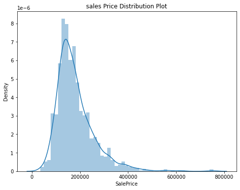

```python
plt.figure(figsize=(8,6))
plt.title('sales Price Distribution Plot')
sns.distplot(house.SalePrice)
plt.show()
```

### **Most of the house have prices between 100000 to 300000**

## **Salesprice by overall quality**

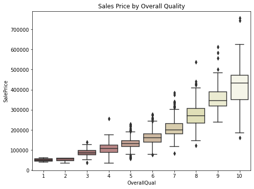

```python
plt.figure(figsize=(8, 6))
sns.boxplot(x='OverallQual', y='SalePrice', data=house, palette='pink')
title = plt.title('Sales Price by Overall Quality')
```

### **Higher the quality of house, more expensive the sales price**

## **Salesprice by Garage cars**

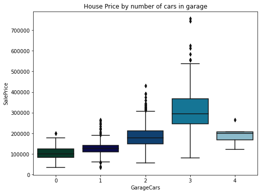

```python
plt.figure(figsize=(8, 6))
sns.boxplot(x='GarageCars', y='SalePrice', data=house, palette='ocean')
title = plt.title('House Price by number of cars in garage')
```

## **Salesprice by Neighbourhood**

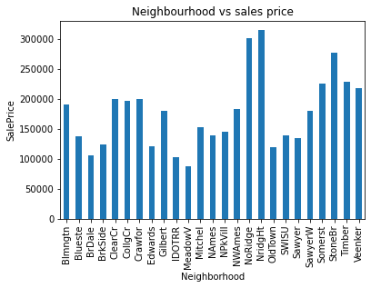

```python
house.groupby('Neighborhood')['SalePrice'].median().plot.bar()
plt.xlabel('Neighborhood')
plt.ylabel('SalePrice')
plt.title('Neighbourhood vs sales price')
plt.show()
```

### **NoRidge, NridgHt and StoneBr are top 3 most expensive neighbourhood and also they are around 3 times costlier than top 3 cheapest neighbourhood which is Meadow, IDOTRR and BrDale**

## **Sales price by Year built**

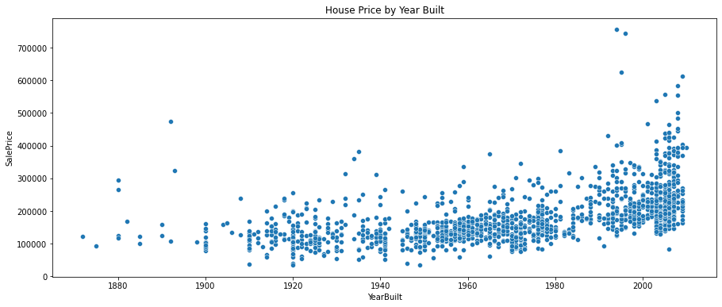

```python
plt.figure(figsize=(15, 6))
sns.scatterplot(x='YearBuilt', y='SalePrice', data=house)
title = plt.title('House Price by Year Built')
```

# **Correlation Analysis**

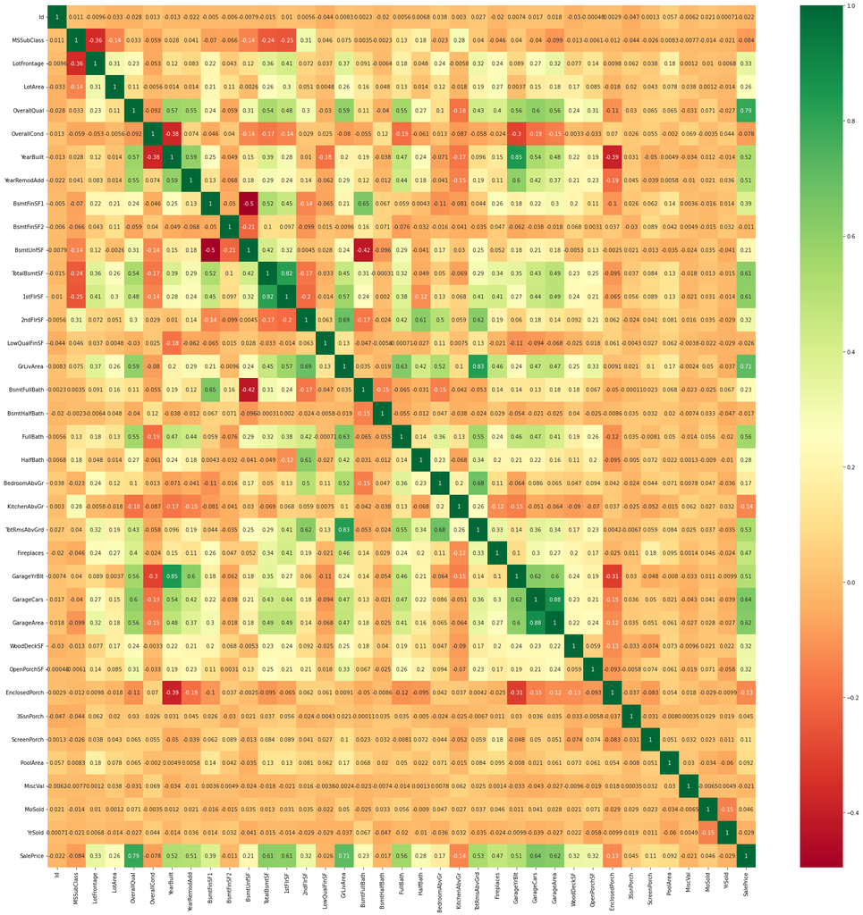

```python
corrmat=house.corr()
top_corr_feature=corrmat.index
plt.figure(figsize=(30,30))
g=sns.heatmap(house[top_corr_feature].corr(), annot=True,cmap="RdYlGn")
```

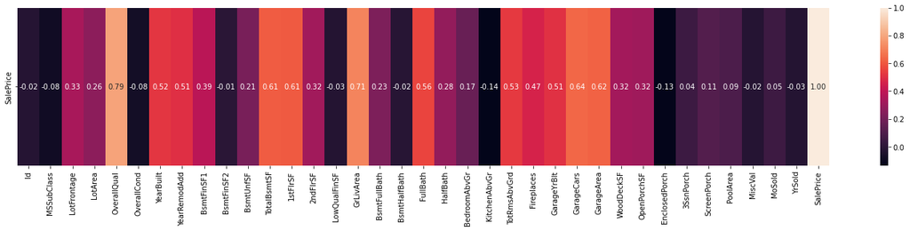

```python
num = house.select_dtypes(exclude = 'object')
numcorr = house.corr()
f, ax = plt.subplots(figsize = (25,4)) # set figure size
sns.heatmap(numcorr.sort_values(by = 'SalePrice', ascending = False).head(1), annot = True, fmt = ".2f")
plt.show()
```

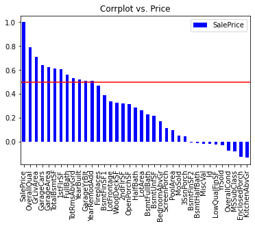

```python
numcorr['SalePrice'].sort_values(ascending = False).to_frame().plot.bar(color = 'blue')
plt.axhline(y = 0.5, color = 'r', linestyle = '-')
plt.title('Corrplot vs. Price')
plt.show()
```

### **There are 11 highly correlated features and 26 positive correlated features**

# **Feature Engineering**

```python
house['TotalSqFeet'] = house['TotalBsmtSF'] + house['1stFlrSF'] + house['2ndFlrSF']
house['TotalBathrooms'] = house['FullBath'] + house['BsmtFullBath'] + 0.5 * (house['HalfBath'] + house['BsmtHalfBath'])
house['HouseAge'] = house['YrSold'] - house['YearBuilt']
house['GarageAge'] = house['YrSold'] - house['GarageYrBlt']
house['RemodelAge']= house['YrSold'] - house['YearRemodAdd']
```

```python
newhouse=house.drop(columns=['TotalBsmtSF', '1stFlrSF', '2ndFlrSF', 'FullBath', 'BsmtFullBath', 'HalfBath', 'BsmtHalfBath', 'YrSold', 'YearBuilt', 'GarageYrBlt', 'YearRemodAdd','Id'], axis=1)
```

```python
newhouse.shape
```

```
(1460, 74)
```

# **ONE HOT ENCODING**

```python
newhouse=newhouse[:1459]
```

```python
newhouse_X =  newhouse.copy()
newhouse_X.drop(['SalePrice'],axis=1,inplace=True)
newhouse_y = newhouse['SalePrice']
```

```python
newhouse_x= newhouse_X.iloc[:,:].values
```

```python
type(newhouse_x)
```

```
numpy.ndarray
```

```python
list(newhouse_x[0,:])
```

```
[60,
 'RL',
 65.0,
 8450,
 'Pave',
 'NA',
 'Reg',
 'Lvl',
 'AllPub',
 'Inside',
 'Gtl',
 'CollgCr',
 'Norm',
 'Norm',
 '1Fam',
 '2Story',
 7,
 5,
 'Gable',
 'CompShg',
 'VinylSd',
 'VinylSd',
 'BrkFace',
 196.0,
 'Gd',
 'TA',
 'PConc',
 'Gd',
 'TA',
 'No',
 'GLQ',
 706,
 'Unf',
 0,
 150,
 'GasA',
 'Ex',
 'Y',
 'SBrkr',
 0,
```

[output cut: 18 more lines]

```
 0,
 0,
 0,
 'NA',
 'NA',
 'None',
 0,
 2,
 'WD',
 'Normal',
 2566,
 3.5,
 5,
 5.0,
 5]
```

```python
columns_ohe = [1,4,5,6,7,8,9,10,
11,12,13,14,15,18,19,20,
21,22,24,25,26,27,28,29,30,
32,35,36,37,38,43,45,47,48,49,
52,53,54,61,62,63,66,67]
```

```python
from tqdm import tqdm
```

```python
for num in tqdm(columns_ohe):
    dummy_=pd.get_dummies(newhouse_x[:,num],sparse=True)
    if(num!=1):
        dummy = np.concatenate((dummy,dummy_),axis=1)
    else:
        dummy = dummy_
```

```python
newhouse_x = np.delete(newhouse_x,columns_ohe,1)
```

```python
newhouse_x
```

```
array([[60, 65.0, 8450, ..., 5, 5.0, 5],
       [20, 80.0, 9600, ..., 31, 31.0, 31],
       [60, 68.0, 11250, ..., 7, 7.0, 6],
       ...,
       [20, 85.0, 13175, ..., 32, 32.0, 22],
       [70, 66.0, 9042, ..., 69, 69.0, 4],
       [20, 68.0, 9717, ..., 60, 60.0, 14]], dtype=object)
```

```python
newhouse_x = np.concatenate((newhouse_x,dummy),axis=1)
```

```python
newhouse_x
```

```
array([[60, 65.0, 8450, ..., 0, 1, 0],
       [20, 80.0, 9600, ..., 0, 1, 0],
       [60, 68.0, 11250, ..., 0, 1, 0],
       ...,
       [20, 85.0, 13175, ..., 0, 1, 0],
       [70, 66.0, 9042, ..., 0, 1, 0],
       [20, 68.0, 9717, ..., 0, 1, 0]], dtype=object)
```

```python
list(newhouse_x[0,:])
```

```
[60,
 65.0,
 8450,
 7,
 5,
 196.0,
 706,
 0,
 150,
 0,
 1710,
 3,
 1,
 8,
 0,
 2,
 548,
 0,
 61,
 0,
 0,
 0,
 0,
 0,
 2,
 2566,
 3.5,
 5,
 5.0,
 5,
 0,
 0,
 0,
 1,
 0,
 0,
 1,
 0,
 1,
 0,
```

[output cut: 241 more lines]

```
 0,
 0,
 0,
 0,
 0,
 0,
 0,
 0,
 1,
 0,
 0,
 0,
 0,
 1,
 0]
```

# **Data Splitting**

```python
np.random.seed(0)
number_of_samples = len(newhouse_x)
random_indices = np.random.permutation(number_of_samples)
num_training_samples = int(number_of_samples*0.75)
```

```python
newhouse_x_train = newhouse_x[random_indices[:num_training_samples]]
newhouse_y_train=newhouse_y[random_indices[:num_training_samples]]
newhouse_x_validation=newhouse_x[random_indices[num_training_samples:]]
newhouse_y_validation=newhouse_y[random_indices[num_training_samples:]]
```

```python
len(newhouse_x_train)
```

```
1094
```

```python
len(newhouse_y_train)
```

```
1094
```

```python
len(newhouse_x_validation)
```

```
365
```

```python
len(newhouse_y_validation)
```

```
365
```

# **Standard scaling**

```python
from sklearn.preprocessing import StandardScaler
scaler = StandardScaler()
# Fit on training set only.
scaler.fit(newhouse_x_train)
# Apply transform to both the training set and the test set.
newhouse_x_train = scaler.transform(newhouse_x_train)
newhouse_x_validation = scaler.transform(newhouse_x_validation)
```

```python
newhouse_x_train.shape
```

```
(1094, 296)
```

```python
newhouse_x_validation.shape
```

```
(365, 296)
```

# **Principal component analysis**

```python
from sklearn.decomposition import PCA
# Make an instance of the Model
pca = PCA(.95)
pca.fit(newhouse_x_train)
newhouse_x_train = pca.transform(newhouse_x_train)
newhouse_x_validation = pca.transform(newhouse_x_validation)
```

```python
newhouse_x_train.shape
```

```
(1094, 171)
```

```python
newhouse_x_validation.shape
```

```
(365, 171)
```

# **Linear Regression**

```python
from sklearn.linear_model import LinearRegression
model = LinearRegression()
model.fit(newhouse_x_train, newhouse_y_train)
newhouse_linear_train_predicted = model.predict(newhouse_x_train)
newhouse_linear_validation_predicted = model.predict(newhouse_x_validation)
```

```python
from sklearn.metrics import r2_score,mean_squared_error
r2_score(newhouse_y_train, newhouse_linear_train_predicted)
```

```
0.9221670165804232
```

```python
r2_score(newhouse_y_validation, newhouse_linear_validation_predicted)
```

```
0.6340015782872432
```

```
Training data -Mean squared error: 535394736.39
Validation data - Mean squared error: 1662649985.59
Training data Coefficient of determination: 0.92
Validation data Coefficient of determination: 0.63
```

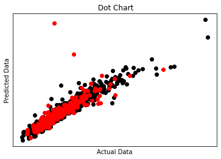

```python
# The mean squared error
print("Training data -Mean squared error: %.2f" % mean_squared_error(newhouse_y_train, newhouse_linear_train_predicted))
print("Validation data - Mean squared error: %.2f" % mean_squared_error(newhouse_y_validation, newhouse_linear_validation_predicted))
# The coefficient of determination: 1 is perfect prediction
print("Training data Coefficient of determination: %.2f" % r2_score(newhouse_y_train, newhouse_linear_train_predicted))
print("Validation data Coefficient of determination: %.2f" % r2_score(newhouse_y_validation, newhouse_linear_validation_predicted))
plt.scatter(newhouse_y_train, newhouse_linear_train_predicted, color="black")
plt.scatter(newhouse_y_validation, newhouse_linear_validation_predicted, color="red")
plt.xticks(())
plt.yticks(())
plt.title(" Dot Chart")
plt.xlabel("Actual Data")
plt.ylabel("Predicted Data")
plt.show()
```

### **There is a change of 29%**

# **Decision tree regressor**

```python
from sklearn.tree import DecisionTreeRegressor

decision = DecisionTreeRegressor(random_state=0)
decision.fit(newhouse_x_train, newhouse_y_train)
decision_train_predicted = decision.predict(newhouse_x_train)
decision_validation_predicted = decision.predict(newhouse_x_validation)
```

```python
r2_score(newhouse_y_train, decision_train_predicted)
```

```
1.0
```

```python
r2_score(newhouse_y_validation, decision_validation_predicted)
```

```
0.6209806038008174
```

```
Training data -Mean squared error: 0.00
Validation data - Mean squared error: 1721801396.52
Training data Coefficient of determination: 1.00
Validation data Coefficient of determination: 0.62
```

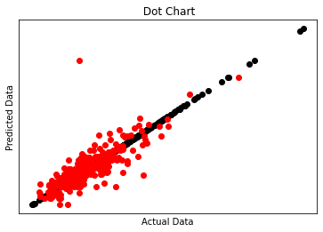

```python
# The mean squared error
print("Training data -Mean squared error: %.2f" % mean_squared_error(newhouse_y_train, decision_train_predicted))
print("Validation data - Mean squared error: %.2f" % mean_squared_error(newhouse_y_validation, decision_validation_predicted))
# The coefficient of determination: 1 is perfect prediction
print("Training data Coefficient of determination: %.2f" % r2_score(newhouse_y_train, decision_train_predicted))
print("Validation data Coefficient of determination: %.2f" % r2_score(newhouse_y_validation, decision_validation_predicted))
plt.scatter(newhouse_y_train, decision_train_predicted, color="black")
plt.scatter(newhouse_y_validation, decision_validation_predicted, color="red")
plt.xticks(())
plt.yticks(())
plt.title(" Dot Chart")
plt.xlabel("Actual Data")
plt.ylabel("Predicted Data")
plt.show()
```

### **Change of 38%**

# **Ridge regression**

```python
from sklearn.linear_model import Ridge
ridge = Ridge()
ridge.fit(newhouse_x_train, newhouse_y_train)

#model evaluation
ridge_train_predicted = ridge.predict(newhouse_x_train)
ridge_validation_predicted = ridge.predict(newhouse_x_validation)
```

```python
r2_score(newhouse_y_train, ridge_train_predicted)
```

```
0.922166947864661
```

```python
r2_score(newhouse_y_validation, ridge_validation_predicted)
```

```
0.6341667382180907
```

```
Training data -Mean squared error: 535395209.07
Validation data - Mean squared error: 1661899700.51
Training data Coefficient of determination: 0.92
Validation data Coefficient of determination: 0.63
```

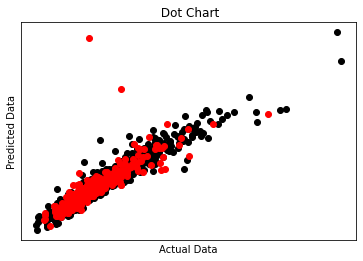

```python
# The mean squared error
print("Training data -Mean squared error: %.2f" % mean_squared_error(newhouse_y_train, ridge_train_predicted))
print("Validation data - Mean squared error: %.2f" % mean_squared_error(newhouse_y_validation, ridge_validation_predicted))
# The coefficient of determination: 1 is perfect prediction
print("Training data Coefficient of determination: %.2f" % r2_score(newhouse_y_train, ridge_train_predicted))
print("Validation data Coefficient of determination: %.2f" % r2_score(newhouse_y_validation, ridge_validation_predicted))
plt.scatter(newhouse_y_train, ridge_train_predicted, color="black")
plt.scatter(newhouse_y_validation, ridge_validation_predicted, color="red")
plt.xticks(())
plt.yticks(())
plt.title(" Dot Chart")
plt.xlabel("Actual Data")
plt.ylabel("Predicted Data")
plt.show()
```

# **Random forest regressor**

```python
from sklearn.ensemble import RandomForestRegressor

regressor = RandomForestRegressor(n_estimators = 100, random_state = 0)

# fit the regressor with x and y data
regressor.fit(newhouse_x_train, newhouse_y_train)
random_train_predicted = regressor.predict(newhouse_x_train)
random_validation_predicted = regressor.predict(newhouse_x_validation)
```

```python
r2_score(newhouse_y_train, random_train_predicted)
```

```
0.9772660198665699
```

```python
r2_score(newhouse_y_validation, random_validation_predicted)
```

```
0.7667369411906736
```

```
Training data -Mean squared error: 156381687.63
Validation data - Mean squared error: 1059662551.42
Training data Coefficient of determination: 0.98
Validation data Coefficient of determination: 0.77
```

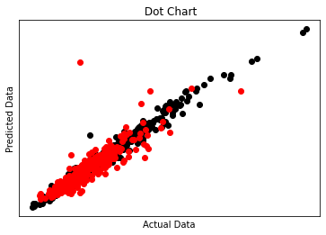

```python
# The mean squared error
print("Training data -Mean squared error: %.2f" % mean_squared_error(newhouse_y_train, random_train_predicted))
print("Validation data - Mean squared error: %.2f" % mean_squared_error(newhouse_y_validation, random_validation_predicted))
# The coefficient of determination: 1 is perfect prediction
print("Training data Coefficient of determination: %.2f" % r2_score(newhouse_y_train, random_train_predicted))
print("Validation data Coefficient of determination: %.2f" % r2_score(newhouse_y_validation, random_validation_predicted))
plt.scatter(newhouse_y_train, random_train_predicted, color="black")
plt.scatter(newhouse_y_validation, random_validation_predicted, color="red")
plt.xticks(())
plt.yticks(())
plt.title(" Dot Chart")
plt.xlabel("Actual Data")
plt.ylabel("Predicted Data")
plt.show()
```

### **Change of 21%**

## **Best Regression model is Random forest regressor with accuracy of 77%**

# **Using the Random regressor on future data**

```python
future=pd.read_csv('Future Data.csv')
pd.set_option("display.max_rows",None)
pd.set_option("display.max_columns",None)
```

```python
future.isnull().sum()
```

```
Id                  0
MSSubClass          0
MSZoning            4
LotFrontage       227
LotArea             0
Street              0
Alley            1352
LotShape            0
LandContour         0
Utilities           2
LotConfig           0
LandSlope           0
Neighborhood        0
Condition1          0
Condition2          0
BldgType            0
HouseStyle          0
OverallQual         0
OverallCond         0
YearBuilt           0
YearRemodAdd        0
RoofStyle           0
RoofMatl            0
Exterior1st         1
Exterior2nd         1
MasVnrType         16
MasVnrArea         15
ExterQual           0
ExterCond           0
Foundation          0
BsmtQual           44
BsmtCond           45
BsmtExposure       44
BsmtFinType1       42
BsmtFinSF1          1
BsmtFinType2       42
BsmtFinSF2          1
BsmtUnfSF           1
TotalBsmtSF         1
Heating             0
```

[output cut: 26 more lines]

```
WoodDeckSF          0
OpenPorchSF         0
EnclosedPorch       0
3SsnPorch           0
ScreenPorch         0
PoolArea            0
PoolQC           1456
Fence            1169
MiscFeature      1408
MiscVal             0
MoSold              0
YrSold              0
SaleType            1
SaleCondition       0
dtype: int64
```

```python
future['LotFrontage'].fillna(value=house['LotFrontage'].mean(), inplace= True)
future['Alley'].fillna(value='NA', inplace= True)
future['MasVnrType'].fillna(value='None', inplace= True)
future['MasVnrType'].fillna(value='None', inplace= True)
future['MasVnrArea'].fillna(value='0', inplace= True)
future['BsmtQual'].fillna(value='NA', inplace= True)
future['BsmtCond'].fillna(value='NA', inplace= True)
future['BsmtExposure'].fillna(value='NA', inplace= True)
future['BsmtFinType1'].fillna(value='NA', inplace= True)
future['BsmtFinType2'].fillna(value='NA', inplace= True)
future['Electrical'].fillna(value='SBrkr', inplace= True)
future['FireplaceQu'].fillna(value ='NA', inplace=True)
future['GarageType'].fillna(value='NA', inplace= True)
future['GarageYrBlt'] = house['GarageYrBlt'].fillna(house['YearBuilt'], inplace=False)
future['GarageFinish'].fillna(value='NA', inplace= True)
future['GarageQual'].fillna(value='NA', inplace= True)
future['GarageCond'].fillna(value='NA', inplace= True)
future['PoolQC'].fillna(value='NA', inplace= True)
future['Fence'].fillna(value='NA', inplace= True)
future['MiscFeature'].fillna(value='None', inplace= True)
future['MSZoning'].fillna(value='NA', inplace= True)
future['Utilities'].fillna(value='NA', inplace= True)
future['Exterior1st'].fillna(value='NA', inplace= True)
future['Exterior2nd'].fillna(value='NA', inplace= True)
future['BsmtFinSF1'].fillna(value="0", inplace= True)
future['BsmtFinSF2'].fillna(value="0", inplace= True)
future['BsmtUnfSF'].fillna(value="0", inplace= True)
future['TotalBsmtSF'].fillna(value="0", inplace= True)
future['BsmtFullBath'].fillna(value="0", inplace= True)
future['BsmtHalfBath'].fillna(value="0", inplace= True)
future['KitchenQual'].fillna(value='NA', inplace= True)
future['Functional'].fillna(value='NA', inplace= True)
future['GarageArea'].fillna(value="0", inplace= True)
future['GarageCars'].fillna(value="0", inplace= True)
future['SaleType'].fillna(value='NA', inplace= True)
```

```python
future.isnull().sum()
```

```
Id               0
MSSubClass       0
MSZoning         0
LotFrontage      0
LotArea          0
Street           0
Alley            0
LotShape         0
LandContour      0
Utilities        0
LotConfig        0
LandSlope        0
Neighborhood     0
Condition1       0
Condition2       0
BldgType         0
HouseStyle       0
OverallQual      0
OverallCond      0
YearBuilt        0
YearRemodAdd     0
RoofStyle        0
RoofMatl         0
Exterior1st      0
Exterior2nd      0
MasVnrType       0
MasVnrArea       0
ExterQual        0
ExterCond        0
Foundation       0
BsmtQual         0
BsmtCond         0
BsmtExposure     0
BsmtFinType1     0
BsmtFinSF1       0
BsmtFinType2     0
BsmtFinSF2       0
BsmtUnfSF        0
TotalBsmtSF      0
Heating          0
```

[output cut: 26 more lines]

```
WoodDeckSF       0
OpenPorchSF      0
EnclosedPorch    0
3SsnPorch        0
ScreenPorch      0
PoolArea         0
PoolQC           0
Fence            0
MiscFeature      0
MiscVal          0
MoSold           0
YrSold           0
SaleType         0
SaleCondition    0
dtype: int64
```

```python
future['GarageYrBlt']=future['GarageYrBlt'].astype(int)
```

```python
future['GarageYrBlt']=future['GarageYrBlt'].astype(int)
# future['YrSold']=future['YrSold'].astype(int)
# future['YearRemodAdd']=future['YearRemodAdd'].astype(int)
future['TotalBsmtSF']=future['TotalBsmtSF'].astype(int)
future['BsmtFullBath']=future['BsmtFullBath'].astype(int)
future['BsmtHalfBath']=future['BsmtHalfBath'].astype(int)
```

```python
house1=future
```

```python
house1['TotalSqFeet'] = house1['TotalBsmtSF'] + house1['1stFlrSF'] + house1['2ndFlrSF']
house1['TotalBathrooms'] = house1['FullBath'] + house1['BsmtFullBath'] + 0.5 * (house1['HalfBath'] + house1['BsmtHalfBath'])
house1['HouseAge'] = house1['YrSold'] - house1['YearBuilt']
house1['GarageAge'] = house1['YrSold'] - house1['GarageYrBlt']
house1['RemodelAge']= house1['YrSold'] - house1['YearRemodAdd']
```

```python
house2=house1.drop(columns=['TotalBsmtSF', '1stFlrSF', '2ndFlrSF', 'FullBath', 'BsmtFullBath', 'HalfBath', 'BsmtHalfBath', 'YrSold', 'YearBuilt', 'GarageYrBlt', 'YearRemodAdd','Id'], axis=1)
```

```python
house2_X =  house2.copy()
house2_Y = newhouse['SalePrice']
house2_x= house2_X.iloc[:,:].values
```

```python
list(house2_x[0,:])
```

```
[20,
 'RH',
 80.0,
 11622,
 'Pave',
 'NA',
 'Reg',
 'Lvl',
 'AllPub',
 'Inside',
 'Gtl',
 'NAmes',
 'Feedr',
 'Norm',
 '1Fam',
 '1Story',
 5,
 6,
 'Gable',
 'CompShg',
 'VinylSd',
 'VinylSd',
 'None',
 0.0,
 'TA',
 'TA',
 'CBlock',
 'TA',
 'TA',
 'No',
 'Rec',
 468.0,
 'LwQ',
 144.0,
 270.0,
 'GasA',
 'TA',
 'Y',
 'SBrkr',
 0,
```

[output cut: 18 more lines]

```
 0,
 120,
 0,
 'NA',
 'MnPrv',
 'None',
 0,
 6,
 'WD',
 'Normal',
 1778,
 1.0,
 49,
 49,
 49]
```

```python
columns_fut = [1, 4, 5, 6,7,8,9,10,11,12,13,14,15,18,19,20,21,22,24,25,26,27,28,
               29,30,32,35,36,37,38,43,45,47,48,49,52,53,54,61,62,63,66,67]
```

```python
dummy = []
for num in tqdm(columns_fut):
    dummy_ = pd.get_dummies(house2_x[:,num],sparse=True)
    if(num!=1):
        dummy = np.concatenate((dummy,dummy_),axis=1)
    else:
        dummy = dummy_
```

```python
house2_x = np.delete(house2_x,columns_ohe,1)
house2_x = np.concatenate((house2_x,dummy),axis=1)
list(house2_x[1,:])
```

```
[20,
 81.0,
 14267,
 6,
 6,
 108.0,
 923.0,
 0.0,
 406.0,
 0,
 1329,
 3,
 1,
 6,
 0,
 1.0,
 312.0,
 393,
 36,
 0,
 0,
 0,
 0,
 12500,
 6,
 2658,
 1.5,
 52,
 52,
 52,
 0,
 0,
 0,
 0,
 1,
 0,
 0,
 1,
 0,
 1,
```

[output cut: 230 more lines]

```
 0,
 0,
 0,
 0,
 0,
 0,
 0,
 0,
 1,
 0,
 0,
 0,
 0,
 1,
 0]
```

```python
np.random.seed(0)
number_of_samples = len(house2_x)
random_indices = np.random.permutation(number_of_samples)
num_training_samples = int(number_of_samples*0.75)
house2_x_train = house2_x[random_indices[:num_training_samples]]
house2_y_train=house2_Y[random_indices[:num_training_samples]]
house2_x_validation=house2_x[random_indices[num_training_samples:]]
house2_y_validation=house2_Y[random_indices[num_training_samples:]]
```

```python
from sklearn.preprocessing import StandardScaler
scaler = StandardScaler()
# Fit on training set only.
scaler.fit(house2_x_train)
# Apply transform to both the training set and the test set.
house2_x_train = scaler.transform(house2_x_train)
house2_x_validation = scaler.transform(house2_x_validation)
```

```python
from sklearn.decomposition import PCA
# Make an instance of the Model
pca = PCA(.95)
pca.fit(house2_x_train)
house2_x_train = pca.transform(house2_x_train)
house2_x_validation = pca.transform(house2_x_validation)
```

```python
from sklearn.ensemble import RandomForestRegressor

regressor = RandomForestRegressor(n_estimators = 100, random_state = 0)

# fit the regressor with x and y data
regressor.fit(house2_x_train, house2_y_train)
random_train_predicted = regressor.predict(house2_x_train)
random_validation_predicted = regressor.predict(house2_x_validation)
```

```python
r2_score(house2_y_train, random_train_predicted)
```

```
0.8488025434410693
```

```python
r2_score(house2_y_validation, random_validation_predicted)
```

```
-0.19039738332201583
```

```
Training data -Mean squared error: 1040051644.45
Validation data - Mean squared error: 5407712369.28
Training data Coefficient of determination: 0.85
Validation data Coefficient of determination: -0.19
```

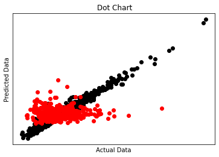

```python
# The mean squared error
print("Training data -Mean squared error: %.2f" % mean_squared_error(house2_y_train, random_train_predicted))
print("Validation data - Mean squared error: %.2f" % mean_squared_error(house2_y_validation, random_validation_predicted))
# The coefficient of determination: 1 is perfect prediction
print("Training data Coefficient of determination: %.2f" % r2_score(house2_y_train, random_train_predicted))
print("Validation data Coefficient of determination: %.2f" % r2_score(house2_y_validation, random_validation_predicted))
plt.scatter(house2_y_train, random_train_predicted, color="black")
plt.scatter(house2_y_validation, random_validation_predicted, color="red")
plt.xticks(())
plt.yticks(())
plt.title(" Dot Chart")
plt.xlabel("Actual Data")
plt.ylabel("Predicted Data")
plt.show()
```

```python
pd.DataFrame(random_validation_predicted)
```

|  | 0 |
| --- | --- |
| 0 | 189230.43 |
| 1 | 217037.16 |
| 2 | 211097.35 |
| 3 | 194012.90 |
| 4 | 204576.74 |
| 5 | 167407.64 |
| 6 | 172831.68 |
| 7 | 202084.92 |
| 8 | 199081.96 |
| 9 | 170195.16 |
| 10 | 188140.88 |
| 11 | 205768.77 |
| 12 | 187010.20 |
| 13 | 216577.75 |
| 14 | 178185.91 |
| 15 | 189344.16 |
| 16 | 212725.99 |
| 17 | 162887.85 |
| 18 | 202539.53 |
| 19 | 200535.27 |
| 20 | 189097.02 |
| 21 | 192084.22 |
| 22 | 177637.91 |
| 23 | 184802.02 |
| 24 | 224376.86 |
| 25 | 200405.81 |
| 26 | 202226.19 |
| 27 | 210145.76 |
| 28 | 190542.37 |
| 29 | 154530.14 |

[output cut: 335 more lines]